# Assignemt_2(K-NN classification)

Uday Kiran

2024-02-25

```r
library('caret')
library('ISLR')
library('dplyr')
library('class')
library('gmodels')
library('FNN')
```

```r
library("ggplot2")
```

#importing data set universitybank.csv

```r
UniversalBank<-read.csv('/Users/udaykirang/Downloads/UniversalBank.csv')
summary(UniversalBank)
```

```
##        ID            Age          Experience       Income          ZIP.Code
##  Min.   :   1   Min.   :23.00   Min.   :-3.0   Min.   :  8.00   Min.   : 9307
##  1st Qu.:1251   1st Qu.:35.00   1st Qu.:10.0   1st Qu.: 39.00   1st Qu.:91911
##  Median :2500   Median :45.00   Median :20.0   Median : 64.00   Median :93437
##  Mean   :2500   Mean   :45.34   Mean   :20.1   Mean   : 73.77   Mean   :93152
##  3rd Qu.:3750   3rd Qu.:55.00   3rd Qu.:30.0   3rd Qu.: 98.00   3rd Qu.:94608
##  Max.   :5000   Max.   :67.00   Max.   :43.0   Max.   :224.00   Max.   :96651
##      Family          CCAvg          Education        Mortgage
##  Min.   :1.000   Min.   : 0.000   Min.   :1.000   Min.   :  0.0
##  1st Qu.:1.000   1st Qu.: 0.700   1st Qu.:1.000   1st Qu.:  0.0
##  Median :2.000   Median : 1.500   Median :2.000   Median :  0.0
##  Mean   :2.396   Mean   : 1.938   Mean   :1.881   Mean   : 56.5
##  3rd Qu.:3.000   3rd Qu.: 2.500   3rd Qu.:3.000   3rd Qu.:101.0
##  Max.   :4.000   Max.   :10.000   Max.   :3.000   Max.   :635.0
##  Personal.Loan   Securities.Account   CD.Account         Online
##  Min.   :0.000   Min.   :0.0000     Min.   :0.0000   Min.   :0.0000
##  1st Qu.:0.000   1st Qu.:0.0000     1st Qu.:0.0000   1st Qu.:0.0000
##  Median :0.000   Median :0.0000     Median :0.0000   Median :1.0000
##  Mean   :0.096   Mean   :0.1044     Mean   :0.0604   Mean   :0.5968
##  3rd Qu.:0.000   3rd Qu.:0.0000     3rd Qu.:0.0000   3rd Qu.:1.0000
##  Max.   :1.000   Max.   :1.0000     Max.   :1.0000   Max.   :1.0000
##    CreditCard
##  Min.   :0.000
##  1st Qu.:0.000
##  Median :0.000
##  Mean   :0.294
##  3rd Qu.:1.000
##  Max.   :1.000
```

```r
UniversalBank$ID<-NULL
UniversalBank$ZIP.Code<-NULL
summary(UniversalBank)
```

```
##       Age          Experience       Income           Family
##  Min.   :23.00   Min.   :-3.0   Min.   :  8.00   Min.   :1.000
##  1st Qu.:35.00   1st Qu.:10.0   1st Qu.: 39.00   1st Qu.:1.000
##  Median :45.00   Median :20.0   Median : 64.00   Median :2.000
##  Mean   :45.34   Mean   :20.1   Mean   : 73.77   Mean   :2.396
##  3rd Qu.:55.00   3rd Qu.:30.0   3rd Qu.: 98.00   3rd Qu.:3.000
##  Max.   :67.00   Max.   :43.0   Max.   :224.00   Max.   :4.000
##      CCAvg          Education        Mortgage     Personal.Loan
##  Min.   : 0.000   Min.   :1.000   Min.   :  0.0   Min.   :0.000
##  1st Qu.: 0.700   1st Qu.:1.000   1st Qu.:  0.0   1st Qu.:0.000
##  Median : 1.500   Median :2.000   Median :  0.0   Median :0.000
##  Mean   : 1.938   Mean   :1.881   Mean   : 56.5   Mean   :0.096
##  3rd Qu.: 2.500   3rd Qu.:3.000   3rd Qu.:101.0   3rd Qu.:0.000
##  Max.   :10.000   Max.   :3.000   Max.   :635.0   Max.   :1.000
##  Securities.Account   CD.Account         Online         CreditCard
##  Min.   :0.0000     Min.   :0.0000   Min.   :0.0000   Min.   :0.000
##  1st Qu.:0.0000     1st Qu.:0.0000   1st Qu.:0.0000   1st Qu.:0.000
##  Median :0.0000     Median :0.0000   Median :1.0000   Median :0.000
##  Mean   :0.1044     Mean   :0.0604   Mean   :0.5968   Mean   :0.294
##  3rd Qu.:0.0000     3rd Qu.:0.0000   3rd Qu.:1.0000   3rd Qu.:1.000
##  Max.   :1.0000     Max.   :1.0000   Max.   :1.0000   Max.   :1.000
```

#Making the Personal Loan column as factor

```r
UniversalBank$Personal.Loan = as.factor(UniversalBank$Personal.Loan)
```

#Normalization

```r
Normal_Data <- preProcess(UniversalBank,method = "range")
UniversalBank_Norm <- predict(Normal_Data,UniversalBank)
summary(UniversalBank_Norm)
```

```
##       Age           Experience         Income           Family
##  Min.   :0.0000   Min.   :0.0000   Min.   :0.0000   Min.   :0.0000
##  1st Qu.:0.2727   1st Qu.:0.2826   1st Qu.:0.1435   1st Qu.:0.0000
##  Median :0.5000   Median :0.5000   Median :0.2593   Median :0.3333
##  Mean   :0.5077   Mean   :0.5023   Mean   :0.3045   Mean   :0.4655
##  3rd Qu.:0.7273   3rd Qu.:0.7174   3rd Qu.:0.4167   3rd Qu.:0.6667
##  Max.   :1.0000   Max.   :1.0000   Max.   :1.0000   Max.   :1.0000
##      CCAvg          Education         Mortgage       Personal.Loan
##  Min.   :0.0000   Min.   :0.0000   Min.   :0.00000   0:4520
##  1st Qu.:0.0700   1st Qu.:0.0000   1st Qu.:0.00000   1: 480
##  Median :0.1500   Median :0.5000   Median :0.00000
##  Mean   :0.1938   Mean   :0.4405   Mean   :0.08897
##  3rd Qu.:0.2500   3rd Qu.:1.0000   3rd Qu.:0.15906
##  Max.   :1.0000   Max.   :1.0000   Max.   :1.00000
##  Securities.Account   CD.Account         Online         CreditCard
##  Min.   :0.0000     Min.   :0.0000   Min.   :0.0000   Min.   :0.000
##  1st Qu.:0.0000     1st Qu.:0.0000   1st Qu.:0.0000   1st Qu.:0.000
##  Median :0.0000     Median :0.0000   Median :1.0000   Median :0.000
##  Mean   :0.1044     Mean   :0.0604   Mean   :0.5968   Mean   :0.294
##  3rd Qu.:0.0000     3rd Qu.:0.0000   3rd Qu.:1.0000   3rd Qu.:1.000
##  Max.   :1.0000     Max.   :1.0000   Max.   :1.0000   Max.   :1.000
```

#Partition the data into training 60% and validation 40% sets

```r
Train_index <- createDataPartition(UniversalBank$Personal.Loan, p = 0.6, list = FALSE)
train.df = UniversalBank_Norm[Train_index,]
validation.df = UniversalBank_Norm[-Train_index,]
```

#Q1 #Classifying the customer as per the date provided #Age = 40, Experience = 10, Income = 84, Family = 2, CCAvg = 2, Education_1 = 0, Education_2 = 1, Education_3 = 0, Mortgage = 0, Securities Account = 0, CD Account = 0, Online = 1, and Credit Card = 1. Perform a k-NN classification with all predictors except ID and ZIP code using k = 1. Remember to transform categorical predictors with more than two categories into dummy variables first. Specify the success class as 1 (loan acceptance), and use the default cutoff value of 0.5.

```r
To_Predict = data.frame(Age = 40, Experience = 10, Income = 84, Family = 2, CCAvg = 2, Education = 1, Mortgage = 0, Securities.Account = 0, CD.Account = 0, Online = 1, CreditCard = 1)
print(To_Predict)
```

```
##   Age Experience Income Family CCAvg Education Mortgage Securities.Account
## 1  40         10     84      2     2         1        0                  0
##   CD.Account Online CreditCard
## 1          0      1          1
```

```r
Prediction <- knn(train = train.df[,1:7],test = To_Predict[,1:7], cl = train.df$Personal.Loan, k = 1)
print(Prediction)
```

```
## [1] 1
## attr(,"nn.index")
##      [,1]
## [1,]  390
## attr(,"nn.dist")
##          [,1]
## [1,] 92.36127
## Levels: 1
```

#Customer is classified as 1.

#Q2 #What is a choice of k that balances between overfitting and ignoring the predictor information? #Calculating the accuracy for each value of k. #Setting the range of k values.

```r
set.seed(2808)
UniversalBank_control <- trainControl(method = "repeatedcv", number = 5, repeats = 2)
searchGrid <- expand.grid(k = 1:10)
knn.model <- train(Personal.Loan ~ ., data = train.df, method = 'knn', tuneGrid = searchGrid, trControl = UniversalBank_control)
knn.model
```

```
## k-Nearest Neighbors
##
## 3000 samples
##   11 predictor
##    2 classes: '0', '1'
##
## No pre-processing
## Resampling: Cross-Validated (5 fold, repeated 2 times)
## Summary of sample sizes: 2400, 2400, 2399, 2400, 2401, 2400, ...
## Resampling results across tuning parameters:
##
##   k   Accuracy   Kappa
##    1  0.9538327  0.7027162
##    2  0.9431683  0.6272423
##    3  0.9516669  0.6668936
##    4  0.9489991  0.6410069
##    5  0.9491658  0.6331219
##    6  0.9471669  0.6145718
##    7  0.9448324  0.5963867
##    8  0.9430008  0.5782569
##    9  0.9415016  0.5619738
##   10  0.9401663  0.5474654
##
## Accuracy was used to select the optimal model using the largest value.
## The final value used for the model was k = 1.
```

#The choice of K that balances between overfitting and ignoring predictor is K=1

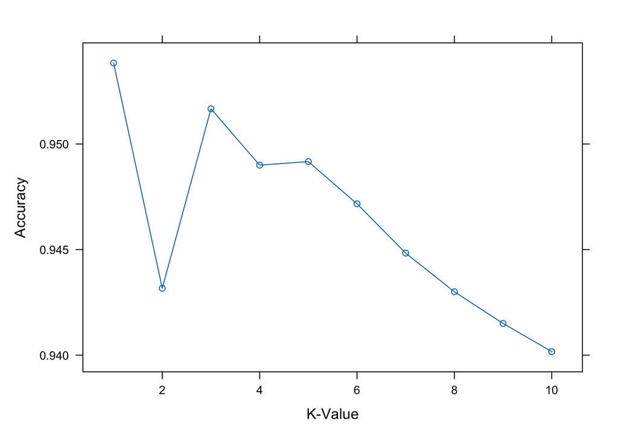

```r
plot(knn.model, type = "b", xlab = "K-Value", ylab = "Accuracy")
```

#fine the best K

```r
best_k <- knn.model$bestTune[[1]]
best_k
```

```
## [1] 1
```

#Q3 #Show the confusion matrix for the validation data that results from using the best k.

```r
predictions <- predict(knn.model,validation.df)
confusionMatrix(predictions,validation.df$Personal.Loan)
```

```
## Confusion Matrix and Statistics
##
##           Reference
## Prediction    0    1
##          0 1792   62
##          1   16  130
##
##                Accuracy : 0.961
##                  95% CI : (0.9516, 0.9691)
##     No Information Rate : 0.904
##     P-Value [Acc > NIR] : < 2.2e-16
##
##                   Kappa : 0.7484
##
##  Mcnemar's Test P-Value : 3.483e-07
##
##             Sensitivity : 0.9912
##             Specificity : 0.6771
##          Pos Pred Value : 0.9666
##          Neg Pred Value : 0.8904
##              Prevalence : 0.9040
##          Detection Rate : 0.8960
##    Detection Prevalence : 0.9270
##       Balanced Accuracy : 0.8341
##
##        'Positive' Class : 0
##
```

#Q4 #Classify the customer using the best k

```r
To_Predict_Normaliz <- data.frame(Age = 40,
                                  Experience = 10,
                                  Income = 84,
                                  Family = 2,
                                  CCAvg = 2,
                                  Education = 1,
                                  Mortgage = 0,
                                  Securities.Account = 0,
                                  CD.Account = 0,
                                  Online = 1,
                                  CreditCard = 1)
To_Predict_Normaliz <- predict(Normal_Data, To_Predict_Normaliz)

prediction <- predict(knn.model, To_Predict_Normaliz)

print(prediction)
```

```
## [1] 0
## Levels: 0 1
```

```r
train_size = 0.5
Train_index = createDataPartition(UniversalBank$Personal.Loan, p = 0.5, list = FALSE)
train.df = UniversalBank_Norm[Train_index,]
test_size = 0.2
Test_index = createDataPartition(UniversalBank$Personal.Loan, p = 0.2, list = FALSE)
Test.df = UniversalBank_Norm[Test_index,]
valid_size = 0.3
Validation_index = createDataPartition(UniversalBank$Personal.Loan, p = 0.3, list = FALSE)
validation.df = UniversalBank_Norm[Validation_index,]
Testingknn <- knn(train = train.df[,-8], test = Test.df[,-8], cl = train.df[,8], k =3)
Validationknn <- knn(train = train.df[,-8],
test = validation.df[,-8], cl = train.df[,8], k =3)
Trainingknn <- knn(train = train.df[,-8],
test = train.df[,-8], cl = train.df[,8], k =3)
```

#Comparing the confusion matrix of the test set with the training and validation sets.

```r
confusionMatrix(Testingknn, Test.df[,8])
```

```
## Confusion Matrix and Statistics
##
##           Reference
## Prediction   0   1
##          0 901  35
##          1   3  61
##
##                Accuracy : 0.962
##                  95% CI : (0.9482, 0.973)
##     No Information Rate : 0.904
##     P-Value [Acc > NIR] : 2.140e-12
##
##                   Kappa : 0.7427
##
##  Mcnemar's Test P-Value : 4.934e-07
##
##             Sensitivity : 0.9967
##             Specificity : 0.6354
##          Pos Pred Value : 0.9626
##          Neg Pred Value : 0.9531
##              Prevalence : 0.9040
##          Detection Rate : 0.9010
##    Detection Prevalence : 0.9360
##       Balanced Accuracy : 0.8160
##
##        'Positive' Class : 0
##
```

```r
confusionMatrix(Trainingknn, train.df[,8])
```

```
## Confusion Matrix and Statistics
##
##           Reference
## Prediction    0    1
##          0 2252   56
##          1    8  184
##
##                Accuracy : 0.9744
##                  95% CI : (0.9674, 0.9802)
##     No Information Rate : 0.904
##     P-Value [Acc > NIR] : < 2.2e-16
##
##                   Kappa : 0.838
##
##  Mcnemar's Test P-Value : 4.228e-09
##
##             Sensitivity : 0.9965
##             Specificity : 0.7667
##          Pos Pred Value : 0.9757
##          Neg Pred Value : 0.9583
##              Prevalence : 0.9040
##          Detection Rate : 0.9008
##    Detection Prevalence : 0.9232
##       Balanced Accuracy : 0.8816
##
##        'Positive' Class : 0
##
```

```r
confusionMatrix(Validationknn, validation.df[,8])
```

```
## Confusion Matrix and Statistics
##
##           Reference
## Prediction    0    1
##          0 1350   47
##          1    6   97
##
##                Accuracy : 0.9647
##                  95% CI : (0.954, 0.9734)
##     No Information Rate : 0.904
##     P-Value [Acc > NIR] : < 2.2e-16
##
##                   Kappa : 0.7667
##
##  Mcnemar's Test P-Value : 3.92e-08
##
##             Sensitivity : 0.9956
##             Specificity : 0.6736
##          Pos Pred Value : 0.9664
##          Neg Pred Value : 0.9417
##              Prevalence : 0.9040
##          Detection Rate : 0.9000
##    Detection Prevalence : 0.9313
##       Balanced Accuracy : 0.8346
##
##        'Positive' Class : 0
##
```